# Doriscar_Jonathan_project2_memo

```r
library(stm)
library(tm)
library(dplyr)
library(readr)
library(tibble)
library(readxl)
library(ggplot2)
library(wordcloud)
library(tidytext)
library(lubridate)
options(scipen = 100)
```

```r
yt_dt <- read.csv("~/Documents/stat 302-1/Final-project-memo-2/youtube_data.csv")
```

## Objective 2

Students are expected to demonstrate that significant progress has been made on their final project since the submission of progress memo 1. Students should have their data cleaned and the EDA should be started.

Demonstrating significant progress means students should have some uni variate and bivariate analyses complete for several of their variables. They should share a few graphics and/or tables with a description of what they have found thus far to demonstrate they progress. Students should should clearly state what they are exploring and why in these demonstrations. That is, they should share the guiding curiosity or research question that accompanies the particular graphics and/or tables they choose to share.

# Familiarizing myself with the distributions of my data set and the nature of the variables.

```r
glimpse(yt_dt)
```

```
Rows: 102,302
Columns: 13
$ video_id             <chr> "0NnTB7J5yRM", "0NnTB7J5yRM", "0NnTB7J5yRM", "0Nn…
$ video_title          <chr> "Victim's attorney: Euclid will pay $450,000 in p…
$ channel_title        <chr> "News 5 Cleveland", "News 5 Cleveland", "News 5 C…
$ subscribers          <int> 273000, 273000, 273000, 273000, 273000, 273000, 2…
$ username             <chr> "K kat", "Pegasus IOS", "Ric Ladouceur", "Diana C…
$ comment              <chr> "This is serious but “My son don’t like him eithe…
$ likes                <int> 15, 14, 7, 1, 13, 4, 5, 1, 2, 2, 0, 1, 1, 0, 0, 0…
$ comment_published_at <chr> "2021-04-09 01:14:21", "2021-05-02 07:33:24", "20…
$ replies              <int> 0, 0, 0, 0, 0, 0, 0, 0, 1, 0, 0, 0, 0, 0, 0, 0, 1…
$ view_count           <int> 9948, 9948, 9948, 9948, 9948, 9948, 9948, 9948, 9…
$ like_count           <int> 104, 104, 104, 104, 104, 104, 104, 104, 104, 104,…
$ comment_count        <int> 29, 29, 29, 29, 29, 29, 29, 29, 29, 29, 29, 29, 2…
$ video_published_at   <chr> "2021-04-08 23:23:12", "2021-04-08 23:23:12", "20…
```

I am familiarizing myself with the nature of the data set to get an idea of the structure of each of my variables.

```r
yt_dt %>%
  group_by(channel_title) %>%
  summarise(n = n(), total_subscribers = sum(subscribers)) %>%
  arrange(desc(total_subscribers))
```

```
# A tibble: 135 × 3
   channel_title         n total_subscribers
   <chr>             <int>             <dbl>
 1 Movieclips         1309       78540000000
 2 ABC News           3511       53700200000
 3 CNN                2319       36527300000
 4 NBC News           3999       36437010000
 5 Law&Crime Network  6445       34615750000
 6 PoliceActivity     6155       32199440000
 7 LastWeekTonight    3310       30562100000
 8 Inside Edition     1592       19929200000
 9 The Young Turks    2181       12219750000
10 NowThis News       3787       10641850000
# ℹ 125 more rows
```

```r
yt_dt %>%
  group_by(channel_title) %>%
  summarise(distinct_videos = n_distinct(video_title),
            total_subscribers = sum(subscribers)) %>%
  arrange(desc(distinct_videos))
```

```
# A tibble: 135 × 3
   channel_title                     distinct_videos total_subscribers
   <chr>                                       <int>             <dbl>
 1 TYT Sports                                      8        2484793000
 2 ABC News                                        6       53700200000
 3 Law&Crime Network                               5       34615750000
 4 NBC News                                        5       36437010000
 5 PoliceActivity                                  4       32199440000
 6 CGTN America                                    3         164129000
 7 Click On Detroit | Local 4 | WDIV               3         927239000
 8 On Demand News                                  3        1212840000
 9 Rossen Law Firm                                 3          23978200
10 ABC 7 Chicago                                   2          66048000
# ℹ 125 more rows
```

```r
yt_dt %>%
  group_by(video_title) %>%
  summarise(n = n(), total_likes = sum(likes)) %>%
  arrange(desc(total_likes))
```

```
# A tibble: 182 × 3
   video_title                                                     n total_likes
   <chr>                                                       <int>       <int>
 1 Cop Caught Arresting the Wrong Man in  Racial Profiling In…  3787     1689602
 2 CAUGHT ON DASH CAM: Citizens Saved from Police Misconduct    1271      509877
 3 Police brutality (Favorite parts Shrek 2)                    1244      464563
 4 Police: Last Week Tonight with John Oliver (HBO)             2160      420115
 5 FEMALE POLICE OFFICER PULLS PISTOL ON COMPLYING MALE         1228      404646
 6 Cop confrontation goes viral                                 1190      328663
 7 Straight Outta Compton (5/10) Movie CLIP - Police Harassme…  1282      241648
 8 I spent a day with SURVIVORS OF POLICE BRUTALITY             1178      240597
 9 Bodycam Shows Florida Police Sergeant Grabbing Female Offi…  1385      214515
10 Unarmed man begs for life, shot by police                    1129      189841
# ℹ 172 more rows
```

```r
yt_dt %>%
  group_by(video_title) %>%
  summarise(n = n(), total_comments = sum(comment_count)) %>%
  arrange(desc(total_comments))
```

```
# A tibble: 182 × 3
   video_title                                                  n total_comments
   <chr>                                                    <int>          <int>
 1 Cop Caught Arresting the Wrong Man in  Racial Profiling…  3787      187662957
 2 Police: Last Week Tonight with John Oliver (HBO)          2160      113844960
 3 Cop confrontation goes viral                              1190       99074640
 4 [WARNING: GRAPHIC] U.S. Army Veteran Settles California…  2551       77671748
 5 FEMALE POLICE OFFICER PULLS PISTOL ON COMPLYING MALE      1228       76999284
 6 Unarmed man begs for life, shot by police                 1129       55428255
 7 CAUGHT ON DASH CAM: Citizens Saved from Police Miscondu…  1271       48911893
 8 Deputy Gets Shot 3 Times During a Wild Shootout With Th…  1392       46093296
 9 Bodycam Shows Florida Police Sergeant Grabbing Female O…  1385       42392080
10 Texas Cop Resigns After Pool Party Confrontation Video …  1254       40461564
# ℹ 172 more rows
```

```r
yt_dt %>%
  group_by(comment) %>%
  summarise(n = n(), comment_replies = sum(replies)) %>%
  arrange(desc(comment_replies))
```

```
# A tibble: 87,241 × 3
   comment                                                     n comment_replies
   <chr>                                                   <int>           <int>
 1 "*meanwhile cops wondering why people hate them so muc…     3            1103
 2 "Meanwhile in louisana...\nQuintin sips a beer while l…     3            1077
 3 "People downplay how traumatic this is. Someone can ju…     3             981
 4 "Sad part he won't get justice. The police will give a…     3             963
 5 "Police: \"I know who you are.\"\nMan: \"Then what´s m…     3             870
 6 "I'm not even black but I felt that when he said \"I'm…     3             732
 7 "I hate how they act like the black guy needs to calm …     3             687
 8 "What kind of parent brings a child into this mess?"        2             652
 9 "Don’t call law enforcement to a domestic if you expec…     2             632
10 "It is so disgusting to keep hearing about settlements…     2             622
# ℹ 87,231 more rows
```

```r
yt_dt <- yt_dt %>%
  group_by(username) %>%
  mutate(distinct_videos_commented = n_distinct(video_title),
         comment_total_username = n()) %>%
  arrange(desc(comment_total_username))
```

```r
yt_dt %>%
  group_by(username) %>%
  summarise(distinct_comments = n_distinct(comment),
            total_comments = n()) %>%
  arrange(desc(distinct_comments))
```

```
# A tibble: 74,102 × 3
   username      distinct_comments total_comments
   <chr>                     <int>          <int>
 1 John                         47             55
 2 John Doe                     42             51
 3 Larry Hohol                  42             42
 4 Michael                      40             47
 5 J                            38             49
 6 David                        37             43
 7 John Smith                   36             40
 8 geisterbahn1                 34             34
 9 Chris                        32             39
10 Edward hickey                30             33
# ℹ 74,092 more rows
```

```r
yt_dt %>%
  group_by(comment) %>%
  summarise(n = n(), comment_likes = sum(likes)) %>%
  arrange(desc(comment_likes))
```

```
# A tibble: 87,241 × 3
   comment                                                       n comment_likes
   <chr>                                                     <int>         <int>
 1 "Meanwhile in louisana...\nQuintin sips a beer while lau…     3        163760
 2 "*meanwhile cops wondering why people hate them so much*"     3        138721
 3 "- White guy gets pepper sprayed\n- Black guy has excess…     1        107960
 4 "Never take off your seatbelt. Never. I’m wearing mine n…     1         80028
 5 "The Pepper spray bit is such a subtle joke but also so …     1         78130
 6 "I hate how they act like the black guy needs to calm do…     3         72290
 7 "People downplay how traumatic this is. Someone can just…     3         68412
 8 "Police: \"I know who you are.\"\nMan: \"Then what´s my …     3         52604
 9 "This entire sequence is peak cinema. Literally from the…     1         43572
10 "Only Shrek could make a joke about drugs, police brutal…     2         42821
# ℹ 87,231 more rows
```

```r
yt_dt %>%
  group_by(username) %>%
  top_n(1, wt = likes) %>%
  summarize(most_likes = max(likes),
            most_liked_comment = first(comment),
            most_likes_replies = max(replies),
            video_title = first(video_title)) %>%
  arrange(desc(most_likes))
```

```
# A tibble: 74,102 × 5
   username         most_likes most_liked_comment most_likes_replies video_title
   <chr>                 <int> <chr>                           <int> <chr>
 1 Ramboost007          107960 "- White guy gets…                500 Police bru…
 2 Jason Hester          80028 "Never take off y…                494 CAUGHT ON …
 3 I am The Batman       78130 "The Pepper spray…                108 Police bru…
 4 Kees_Maarschalk…      54591 "Meanwhile in lou…                359 Cop Caught…
 5 Only Here For M…      46244 "*meanwhile cops …                368 Cop Caught…
 6 PaGaDo                43572 "This entire sequ…                 35 Police bru…
 7 #Beanie-Inkling…      42819 "Only Shrek could…                 77 Police bru…
 8 Chris P. Bacon        28720 "I love how Puss …                329 Police bru…
 9 Silent Bob            28048 "If she’s that ne…                383 FEMALE POL…
10 Steven s              26855 "This is exactly …                472 Cop confro…
# ℹ 74,092 more rows
```

Time Descriptives:

```r
 yt_dt %>%
  mutate(video_published_at = as.POSIXct(video_published_at, format = "%Y-%m-%d %H:%M:%S")) %>%
  arrange(video_published_at, video_title)
```

```
# A tibble: 102,302 × 15
# Groups:   username [74,102]
   video_id    video_title      channel_title subscribers username comment likes
   <chr>       <chr>            <chr>               <int> <chr>    <chr>   <int>
 1 ibSwITK4jjQ Police Brutality muzztard              378 Michael  "If yo…     0
 2 ibSwITK4jjQ Police Brutality muzztard              378 Nick     "not t…     0
 3 ibSwITK4jjQ Police Brutality muzztard              378 steve s… "You a…     0
 4 ibSwITK4jjQ Police Brutality muzztard              378 steve s… "That …     0
 5 ibSwITK4jjQ Police Brutality muzztard              378 steve s… "That …     0
 6 ibSwITK4jjQ Police Brutality muzztard              378 steve s… "He ta…     0
 7 ibSwITK4jjQ Police Brutality muzztard              378 steve s… "Hope …     0
 8 ibSwITK4jjQ Police Brutality muzztard              378 steve s… "The p…     0
 9 ibSwITK4jjQ Police Brutality muzztard              378 steve s… "She g…     0
10 ibSwITK4jjQ Police Brutality muzztard              378 steve s… "That …     0
# ℹ 102,292 more rows
# ℹ 8 more variables: comment_published_at <chr>, replies <int>,
#   view_count <int>, like_count <int>, comment_count <int>,
#   video_published_at <dttm>, distinct_videos_commented <int>,
#   comment_total_username <int>
```

```r
set.seed(1234)
sampled_yt_dt <- yt_dt %>%
  ungroup() %>%  # Remove grouping
  sample_n(10000, replace = FALSE)
```

The data set is so big that these parts of the code move slow, so for the purposes of memo 2 I am going to take a smaller sub sample from this data set and preprocess this.

```r
library(lubridate)
sampled_yt_dt <- sampled_yt_dt %>%
  mutate(comment_published_at = ymd_hms(comment_published_at),
         comment_day_of_week = weekdays(comment_published_at),
         comment_hour_of_day = hour(comment_published_at))
```

```r
sampled_yt_dt %>%
  count(comment_day_of_week) %>%
  arrange(desc(n))
```

```
# A tibble: 7 × 2
  comment_day_of_week     n
  <chr>               <int>
1 Friday               1525
2 Tuesday              1508
3 Wednesday            1474
4 Monday               1461
5 Thursday             1450
6 Saturday             1371
7 Sunday               1211
```

```r
# Explore the distribution of comments over hours of the day
sampled_yt_dt %>%
  count(comment_hour_of_day) %>%
  arrange(desc(n))
```

```
# A tibble: 24 × 2
   comment_hour_of_day     n
                 <int> <int>
 1                  22   535
 2                  20   534
 3                  21   518
 4                  16   514
 5                  18   505
 6                   0   491
 7                  23   491
 8                  19   479
 9                  17   477
10                  15   473
# ℹ 14 more rows
```

```r
sampled_yt_dt <- sampled_yt_dt %>%
  mutate(video_published_at = ymd_hms(video_published_at),
         video_day_of_week = weekdays(video_published_at),
         video_hour_of_day = hour(video_published_at))
```

```r
sampled_yt_dt %>%
  group_by(video_title, video_day_of_week) %>%
  count() %>%
  arrange(video_title, desc(n))
```

```
# A tibble: 166 × 3
# Groups:   video_title, video_day_of_week [166]
   video_title                                           video_day_of_week     n
   <chr>                                                 <chr>             <int>
 1 $5.75 million Columbus police brutality settlement    Friday                6
 2 1969 - When Gays First Fought Back Against Police Br… Wednesday            13
 3 2Pac's experience with police brutality               Saturday              2
 4 3 college students accuse LA County deputies of raci… Friday               99
 5 40+ New Police Brutality videos emerge during the Ge… Monday              224
 6 5 Worst Cases of Police Brutality Caught on Tape      Wednesday            63
 7 6 HORRIFIC Police Brutality Cases                     Tuesday              75
 8 7 Police Officers and Nurse Charged in 2020 Death of… Thursday             28
 9 A Terrible Montage of Police Brutality                Tuesday             145
10 Albuquerque Police Patrol The Streets | FULL EPISODE… Wednesday            21
# ℹ 156 more rows
```

```r
sampled_yt_dt %>%
  group_by(video_title, video_hour_of_day) %>%
  count() %>%
  arrange(video_title, desc(n))
```

```
# A tibble: 166 × 3
# Groups:   video_title, video_hour_of_day [166]
   video_title                                           video_hour_of_day     n
   <chr>                                                             <int> <int>
 1 $5.75 million Columbus police brutality settlement                    4     6
 2 1969 - When Gays First Fought Back Against Police Br…                20    13
 3 2Pac's experience with police brutality                               1     2
 4 3 college students accuse LA County deputies of raci…                 5    99
 5 40+ New Police Brutality videos emerge during the Ge…                 1   224
 6 5 Worst Cases of Police Brutality Caught on Tape                     23    63
 7 6 HORRIFIC Police Brutality Cases                                    18    75
 8 7 Police Officers and Nurse Charged in 2020 Death of…                21    28
 9 A Terrible Montage of Police Brutality                               12   145
10 Albuquerque Police Patrol The Streets | FULL EPISODE…                17    21
# ℹ 156 more rows
```

```r
sampled_yt_dt %>%
  mutate(video_published_at = ymd_hms(video_published_at)) %>%
  group_by(video_published_date = as.Date(video_published_at), video_title) %>%
  summarise(total_likes = sum(like_count)) %>%
  arrange(desc(total_likes)) %>%
  slice(1)
```

```
# A tibble: 149 × 3
# Groups:   video_published_date [149]
   video_published_date video_title                                  total_likes
   <date>               <chr>                                              <int>
 1 2006-07-10           Police Brutality                                  767580
 2 2009-10-03           Police brutality (Favorite parts Shrek 2)       20206494
 3 2010-03-12           Police Brutality at Samoan Bridal Shower in…         160
 4 2010-09-05           Shocking police brutality caught on CCTV           52841
 5 2011-02-21           KRUE “Police Brutality” Official Music Vide…       14784
 6 2011-08-24           Largest Police Brutality Award in Wisconsin…       87126
 7 2011-12-15           Booking leads to police brutality bust             44901
 8 2012-06-20           Police Brutality Worse than Rodney King - T…     1604670
 9 2013-12-02           Shocking video emerges of police brutality …        1152
10 2014-03-07           Police brutality video goes viral                      9
# ℹ 139 more rows
```

# Visualizing the most frequent words in the data set

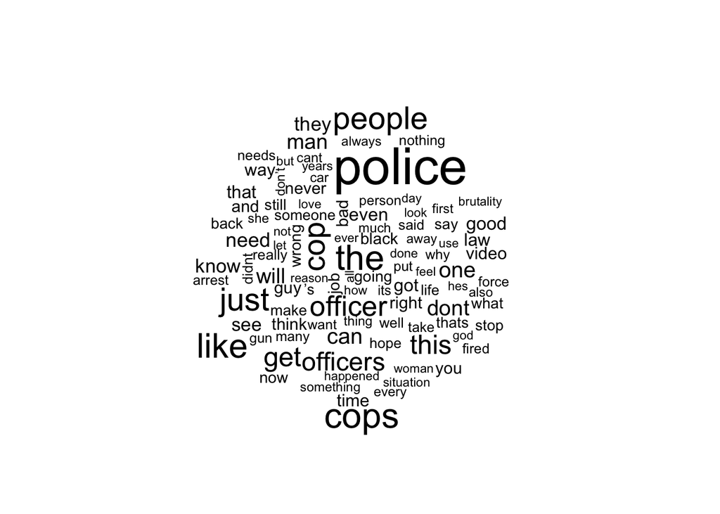

```r
yt_dt %>%
  with(wordcloud(comment, max.words = 100, scale = c(3, 0.5))) # within scale the first value pertains to the font size for the most frequent word while the second is the font size for the least frequent word
```

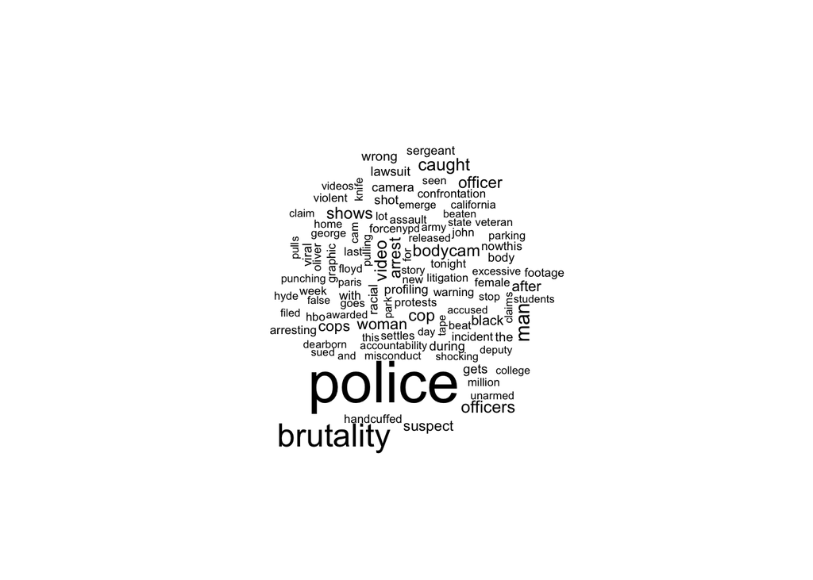

```r
yt_dt %>%
  with(wordcloud(video_title, max.words = 100, scale = c(3, 0.5)))
```

These word clouds are graphics that allow us to see which words are the most popular (the top 100), the scaling argument scales words based on their frequency. What we can see through both word clouds is that police is by far the most common word which makes sense, that being said brutality is popular in titles but does not even appear in the comments as the most frequent. Word clouds are helpful visuals that allow us to more easily see the pattern of words in the comments and titles of these videos.

# Cleaning/Pre-processing —

```r
# Preprocess the comment column in yt_dt
sampled_yt_dt$comment_clean <- tolower(sampled_yt_dt$comment)  # Convert to lowercase
sampled_yt_dt$comment_clean <- gsub("\\d+", "", sampled_yt_dt$comment_clean)  # Remove numbers
sampled_yt_dt$comment_clean <- gsub("[[:punct:]]", "", sampled_yt_dt$comment_clean)  # Remove punctuation
sampled_yt_dt$comment_clean <- removeWords(sampled_yt_dt$comment_clean, stopwords("english"))  # Remove stopwords
sampled_yt_dt$comment_clean <- stripWhitespace(sampled_yt_dt$comment_clean)  # Remove extra whitespaces
```

```r
# Stemming the words in comments
for (i in 1:nrow(sampled_yt_dt)) {
  comment_words <- strsplit(sampled_yt_dt$comment_clean[i], " ")[[1]]  # Split the comment into individual words
  stemmed_words <- stemDocument(comment_words)  # Find the stems of the words
  sampled_yt_dt$comment_clean[i] <- paste(stemmed_words, collapse = " ")  # Replace the comment with the stemmed words
}
```

```r
# Preprocess the comment column in yt_dt
yt_proc <- textProcessor(
  documents = sampled_yt_dt$comment_clean,    # Specify the column containing the comments
  metadata = sampled_yt_dt              # Include metadata if available (optional)
)
```

```
Building corpus...
Converting to Lower Case...
Removing punctuation...
Removing stopwords...
Removing numbers...
Stemming...
Creating Output...
```

```r
# Extract the components from yt_proc object
meta <- yt_proc$meta      # Extract the metadata from yt_proc
vocab <- yt_proc$vocab    # Extract the vocabulary from yt_proc
docs <- yt_proc$documents  # Extract the preprocessed documents from yt_proc

# Prepare the documents for further analysis
yt_out <- prepDocuments(docs, vocab, meta)
```

```
Removing 4996 of 9433 terms (4996 of 105053 tokens) due to frequency
Removing 116 Documents with No Words
Your corpus now has 9739 documents, 4437 terms and 100057 tokens.
```

```r
# Update the variables with the modified values
docs <- yt_out$documents  # Update the documents with the modified values from prepDocuments
vocab <- yt_out$vocab     # Update the vocabulary with the modified values from prepDocuments
meta <- yt_out$meta       # Update the metadata with the modified values from prepDocuments
```

All of this code is part of the data cleaning and pre-processing process. This process is pivotal for later analyses such as calculating sentiment across the comments or employing more advanced methods of statistical analysis such as structural topical modeling. For the purposes of this project memo, I will focus on cleaning and pre-processing the data for the purposes of exploratory data analysis (e.g., identifying frequent words within the comments). During the final project, I will be employing the more advanced methods of analyses. #

Descriptive stuff —

```r
# But how many times does each word appear?
sampled_yt_dt %>%
  unnest_tokens(word, comment_clean) %>%
  count(word, sort = TRUE) %>%
  slice(1:25) # this is letting us the top 25 words
```

```
# A tibble: 25 × 2
   word      n
   <chr> <int>
 1 cop    2185
 2 polic  2072
 3 offic  1724
 4 get    1217
 5 like   1151
 6 peopl  1083
 7 just   1049
 8 need    817
 9 dont    785
10 one     657
# ℹ 15 more rows
```

```r
# Most frequent words by video:
sampled_yt_dt %>%
  unnest_tokens(word, comment) %>%
  anti_join(stop_words) %>%
  count(video_title, word, sort = TRUE) %>%
  group_by(video_title)
```

```
# A tibble: 53,196 × 3
# Groups:   video_title [166]
   video_title                                                       word      n
   <chr>                                                             <chr> <int>
 1 Hyde Park Woman Gets Shot After Pulling Knife on Police Officers  knife   104
 2 40+ New Police Brutality videos emerge during the George Floyd P… poli…    75
 3 Cop Caught Arresting the Wrong Man in  Racial Profiling Incident… cop      67
 4 Cop Caught Arresting the Wrong Man in  Racial Profiling Incident… poli…    61
 5 Police: Last Week Tonight with John Oliver (HBO)                  poli…    58
 6 Cops Rescue Kidnapped Woman Chained to Floor in Kentucky Home     hedge    55
 7 [WARNING: GRAPHIC] U.S. Army Veteran Settles California Police B… cops     55
 8 [WARNING: GRAPHIC] U.S. Army Veteran Settles California Police B… poli…    55
 9 Man awarded $10 million in lawsuit over assault by Dearborn poli… poli…    54
10 Cop Caught Arresting the Wrong Man in  Racial Profiling Incident… offi…    53
# ℹ 53,186 more rows
```

```r
  # filter(n > 1000) %>%
```

```r
# Create a tidy text corpus
corpus <- sampled_yt_dt %>%
  select(video_title, comment_clean) %>%
  unnest_tokens(word, comment_clean)

# Calculate the frequency of each word
word_freq <- corpus %>%
  count(video_title, word, sort = TRUE)

# Get the top n most frequent words for each title
n <- 1
top_words <- word_freq %>%
  group_by(video_title) %>%
  slice_max(n = n, order_by = n)

# Print the top words for each title
print(top_words)
```

```
# A tibble: 367 × 3
# Groups:   video_title [166]
   video_title                                                 word         n
   <chr>                                                       <chr>    <int>
 1 $5.75 million Columbus police brutality settlement          build        3
 2 $5.75 million Columbus police brutality settlement          citi         3
 3 $5.75 million Columbus police brutality settlement          pay          3
 4 $5.75 million Columbus police brutality settlement          peopl        3
 5 $5.75 million Columbus police brutality settlement          tax          3
 6 1969 - When Gays First Fought Back Against Police Brutality thank        4
 7 2Pac's experience with police brutality                     american     1
 8 2Pac's experience with police brutality                     bro          1
 9 2Pac's experience with police brutality                     citizen      1
10 2Pac's experience with police brutality                     control      1
# ℹ 357 more rows
```

```r
# Create a tidy text corpus with bigrams
corpus <- sampled_yt_dt %>%
  select(video_title, comment_clean) %>%
  unnest_tokens(bigram, comment_clean, token = "ngrams", n = 2)

# Calculate the frequency of each bigram
bigram_freq <- corpus %>%
  count(video_title, bigram, sort = TRUE)

# Get the top n most frequent bigrams for each title
n <- 1
top_bigrams <- bigram_freq %>%
  group_by(video_title) %>%
  slice_max(n = n, order_by = n)

# Print the top bigrams for each title
print(top_bigrams)
```

```
# A tibble: 1,883 × 3
# Groups:   video_title [166]
   video_title                                        bigram                   n
   <chr>                                              <chr>                <int>
 1 $5.75 million Columbus police brutality settlement abid citizen             1
 2 $5.75 million Columbus police brutality settlement absolut disgust          1
 3 $5.75 million Columbus police brutality settlement act like                 1
 4 $5.75 million Columbus police brutality settlement add insult               1
 5 $5.75 million Columbus police brutality settlement add tax                  1
 6 $5.75 million Columbus police brutality settlement afraid safeti            1
 7 $5.75 million Columbus police brutality settlement anyon expect             1
 8 $5.75 million Columbus police brutality settlement ask everyth              1
 9 $5.75 million Columbus police brutality settlement assault citi             1
10 $5.75 million Columbus police brutality settlement beautifulthank pigg…     1
# ℹ 1,873 more rows
```

Similar to the word clouds this code allows me to see the most frequent words, but this is for the pre-processed data and the original data so I can compare and I am able to group it by video to see how the most frequent words vary as a function of the video. I am able to also see the top bi-grams by video which provides much more insight into the types of words that are being used in these videos. For example for “3 college students accuse LA County deputies of racial profiling in viral TikTok video” the top uni-gram was arrest, which is not nearly as helpful as its top bi-gram which is resist arrest. This bi-gram gives us insight into the types of conversations that are being had within this video.

# Running inferential analyses to examine bi-variate relationships

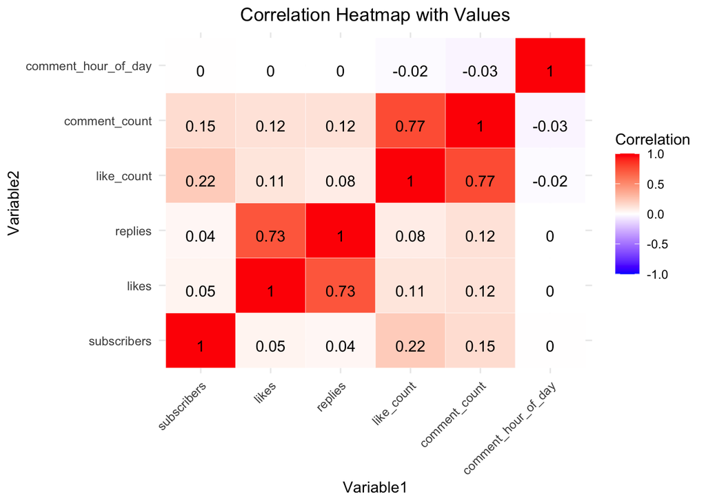

```r
cor_matrix <- cor(sampled_yt_dt[, c("subscribers", "likes", "replies", "like_count", "comment_count", "comment_hour_of_day")])

# Convert the correlation matrix to a data frame for ggplot
cor_df <- as.data.frame(as.table(cor_matrix))
names(cor_df) <- c("Variable1", "Variable2", "Correlation")

# Plot heatmap using ggplot
ggplot(cor_df, aes(Variable1, Variable2, fill = Correlation)) +
  geom_tile(color = "white") +
  scale_fill_gradient2(low = "blue", high = "red", mid = "white",
                       midpoint = 0, limit = c(-1, 1), space = "Lab",
                       name="Correlation") +
  geom_text(aes(label = round(Correlation, 2)), vjust = 1) +
  theme_minimal() +
  theme(axis.text.x = element_text(angle = 45, hjust = 1),
        plot.title = element_text(hjust = 0.5)) +
  ggtitle("Correlation Heatmap with Values")
```

This correlation matrix and heat map plot allows us to view some of the broader relationships between our variables. There are some interesting patterns here. For example comments with more replies also have more likes. Lie count is related to a channels subscribers, and is strongly associated with the amount of comments on the video. There are some interesting patterns here, but I am less interested in these bi-variate relationships. In my final project, I will add several variables such as sentiment and do some more complex analyses such as structural topic modeling so I can understand the text data much better.